# v4

```python
import pandas as pd
import numpy as np
import matplotlib.pyplot as plt
import seaborn as sns
from tabulate import tabulate

from sklearn.preprocessing import scale
from scipy.stats import boxcox
from sklearn.decomposition import PCA


from sklearn.metrics import r2_score
from sklearn.model_selection import train_test_split
from sklearn.neighbors import KNeighborsRegressor
from sklearn.impute import KNNImputer
from sklearn.model_selection import GridSearchCV

from sklearn.linear_model import LinearRegression
from sklearn.linear_model import Ridge
from sklearn.linear_model import Lasso
from sklearn.linear_model import ElasticNet


from sklearn.metrics import r2_score
from sklearn.metrics import mean_squared_error

pd.options.display.max_columns = None
import warnings
warnings.filterwarnings("ignore")
%matplotlib inline
```

**1 - INTRODUCTION**

- This dataset is obtained from kaggle.com. And it is originally scrapped from dubizzle.com. Dubizzle is one of the famous online retail platforms in UAE (United Arab Emirates) to sell or buy any products (it is like US based Craigslist).
- The dataset contains only auto ads from that website. The purpose of this project is to predict the price (continuous variable) of the vehicles using linear regression models and to find best model that fits the dataset.
- The intention is to understand how car sale websites (e.g. KBB, Carvana) estimates the price of the cars within existing information.

Source (Kaggle) : https://www.kaggle.com/datasets/alihassankp/dubizzle-used-car-sale-data

Models : Linear Regression, Ridge, Lasso and ElasticNet

Model Evaluation : R-squared, RMSE , MSE

**2 - DATA EXPLANATION**

This is how dataset looks like before any analysis and processing:

```python
df = pd.read_csv('dubizzle.csv')
df.head(5)
```

|  | title | price_in_aed | kilometers | body_condition | mechanical_condition | seller_type | body_type | no_of_cylinders | transmission_type | regional_specs | horsepower | fuel_type | steering_side | year | color | emirate | motors_trim | company | model | date_posted |
| --- | --- | --- | --- | --- | --- | --- | --- | --- | --- | --- | --- | --- | --- | --- | --- | --- | --- | --- | --- | --- |
| 0 | MITSUBISHI PAJERO 3.5L / 2013 | 26,000 | 167390 | Perfect inside and out | Perfect inside and out | Dealer | SUV | 6 | Automatic Transmission | GCC Specs | Unknown | Gasoline | Left Hand Side | 2013.0 | Silver | Dubai | GLS | mitsubishi | pajero | 13/05/2022 |
| 1 | chevrolet silverado | 110,000 | 39000 | Perfect inside and out | Perfect inside and out | Dealer | SUV | 8 | Automatic Transmission | North American Specs | 400 - 500 HP | Gasoline | Left Hand Side | 2018.0 | White | Sharjah | 1500 High Country | chevrolet | silverado | 14/01/2022 |
| 2 | MERCEDES-BENZ E300 - 2014 - GCC SPEC - FULL OP... | 78,000 | 200000 | Perfect inside and out | Perfect inside and out | Dealer | Sedan | 6 | Automatic Transmission | GCC Specs | 400 - 500 HP | Gasoline | Left Hand Side | 2014.0 | Blue | Sharjah | E 300 | mercedes-benz | e-class | 05/05/2022 |
| 3 | WARRANTY UNTIL APR 2023 \|\| Ferrari 488 Spider ... | 899,000 | 27000 | Perfect inside and out | Perfect inside and out | Dealer | Hard Top Convertible | 8 | Automatic Transmission | GCC Specs | 600 - 700 HP | Gasoline | Left Hand Side | 2018.0 | Red | Dubai | Standard | ferrari | 488-spider | 30/04/2022 |
| 4 | USED RENAULT DOKKER 2020 | 33,000 | 69000 | Perfect inside and out | Perfect inside and out | Owner | Wagon | 4 | Manual Transmission | GCC Specs | Less than 150 HP | Gasoline | Left Hand Side | 2020.0 | White | Dubai | Standard | renault | dokker | 13/05/2022 |

```python
df.shape
```

```
(9970, 20)
```

So our dataset consist of 9970 rows (observations) and 20 columns.

> Here is the explanation of each columns:

title - Vehicle name with model details

price_in_aed - Vehicle price in united arab emirates dhirham

kilometer - How many kilometer the vehicle travelled

body_condition - Body condition of vehicle

mechanical_condition - Mechanical condition of vehicle

seller_type - Type of seller ( Dealer, Owner, Other)

body_type - Body type ( SUV, Sedan, Other)

no_of_cylinder - Number of cylinder

transmission_type - Vehicle transmission type ( Automatic Transmission, Manual Transmission )

regional_spec - Regional Specification of vehicle

horsepower - Horsepower

fuel_type - Fuel Type

steering_side - Steering side of the vehicle

year - Vehicle model year

color - Vehicle color

emirates - Emirates is like state

motor_trim - Motor trim type

company - Vehicle manufacture company name

model - Vehicle model

date_posted - Date of ad posted

```python
df.dtypes
```

```
title                    object
price_in_aed             object
kilometers                int64
body_condition           object
mechanical_condition     object
seller_type              object
body_type                object
no_of_cylinders          object
transmission_type        object
regional_specs           object
horsepower               object
fuel_type                object
steering_side            object
year                    float64
color                    object
emirate                  object
motors_trim              object
company                  object
model                    object
date_posted              object
dtype: object
```

As we see above, most of the columns seem as objects (despite they have numeric values) and they need to be converted integers so we can include them in our regressions.

**3 - DATA PRE-PROCESSING**

```python
# There are 5 columns that has categorical values (e.g. fuel_type: electrical, diesel, gasoline)
# We would like to convert them to dummy variables (e.g. is_diesel: 1/0, is_electrical: 1/0)
# In each categorical value, we ommit one value to avoid having a linear dependency among columns.
# E.g. if there are 3 categories in a column, we convert it to 2 columns with binary values.

# Columns with categorical values, and dummy variable name to drop.
categorical_column_and_drop_dummy_pairs = [
    ('seller_type', 'Owner'),
    ('body_type', 'Other'),
    ('regional_specs', 'Other'),
    ('fuel_type', 'Electric'),
    ('company', 'other-make'),
]

for column, drop_val in categorical_column_and_drop_dummy_pairs:
    # Get individual columns for each dummy.
    dummies = pd.get_dummies(df[column])
    # Drop one dummy to avoid linear dependence
    dummies = dummies.drop(drop_val, axis = 1)
    # Drop the old columns with categorical values
    df = df.drop(column, axis=1)
    # Add dummy columns
    df = pd.concat([df, dummies], axis = 1)

# price column: remove comma from values and convert column to integer
df['price_in_aed'] = df['price_in_aed'].replace(',','', regex= True)
df['price_in_aed'] = df['price_in_aed'].astype(int)


# kilometer column:

df['kilometers'] = df['kilometers'].astype(int)
df = df[df['kilometers'] < 500000] # there were km values that were not possible. We filter them.


#body_condition column : rank the condition from 1 to 4

map_bodycondition = {
    'Perfect inside and out': 4,
    'No accidents, very few faults' : 3,
    'A bit of wear & tear, all repaired': 2,
    'Normal wear & tear, a few issues': 1
}

df['body_condition'] = df['body_condition'].replace(map_bodycondition)

# mechanical_condition column : rank the condition from 1 to 5

map_mechanicalcondition = {
    'Perfect inside and out': 5,
    'Minor faults, all fixed': 4,
    'Major faults, all fixed': 3,
    'Major faults fixed, small remain': 2,
    'Ongoing minor & major faults': 1
}

df['mechanical_condition'] = df['mechanical_condition'].replace(map_mechanicalcondition)

# no_of_cylinders column : replace 'unknown', 'na' and 'none' with 0. convert to integer
# Those are usually electrical vehicles.

df['no_of_cylinders'] = df['no_of_cylinders'].replace(['Unknown', '', 'None'], 0).fillna(0)
df['no_of_cylinders'] = df['no_of_cylinders'].astype(int)

# transmission_type column : convert to binary variable (manual = 0, automatic = 1)

df['transmission_type'] = np.where(df['transmission_type']=='Automatic Transmission',1,0)

# steering_side : convert to binary variable (left side = 1, right side = 0)

df['steering_side'] = np.where(df['steering_side']=='Left Hand Side',1,0)

# horse_power column

map_horsepower = {
    'Less than 150 HP' : 50,
    '150 - 200 HP' : 175,
    '200 - 300 HP' : 250,
    '300 - 400 HP' : 350,
    '400 - 500 HP' : 450,
    '500 - 600 HP' : 550,
    '600 - 700 HP' : 650,
    '700 - 800 HP' : 750,
    '800 - 900 HP' : 850,
    '900+ HP'      : 900,
    'Unknown'      : 0, # Zero values will be imputed below.
}

df['horsepower'] = df['horsepower'].replace(map_horsepower)


# date_posted column: Converting all dates to only year. (since some dates includes d/m/y information, some does not.)
df['date_posted'] = pd.to_datetime(df['date_posted'], errors='coerce').dt.strftime('%Y')
df['date_posted'] = df['date_posted'].astype(int)


# year column:
# Data imputation: We predict missing year values using linear regression.
# Independent variables will be kilometers and date_posted columns, dependent varible will be year.
# We selected those columns as we expect kilometer to be large if the car is old.

df_subset_nonmissing = df.dropna(subset=['year', 'kilometers', 'date_posted'])
model = LinearRegression().fit(df_subset_nonmissing[['kilometers', 'date_posted']], df_subset_nonmissing['year'])
df['year'] = df.apply(lambda row: model.predict([[ row['kilometers'], row['date_posted']]])[0] if pd.isna(row['year']) else row['year'], axis=1)
df['year'] = df['year'].astype(int)

# horsepower column: We'll use the average of the column to impute those missing NaN values.

horsepower_mean = df['horsepower'].mean()
df['horsepower'] = df['horsepower'].replace(0,horsepower_mean)

df.head(5)
```

|  | title | price_in_aed | kilometers | body_condition | mechanical_condition | no_of_cylinders | transmission_type | horsepower | steering_side | year | color | emirate | motors_trim | model | date_posted | Dealer | Dealership/Certified Pre-Owned | Coupe | Crossover | Hard Top Convertible | Hatchback | Pick Up Truck | SUV | Sedan | Soft Top Convertible | Sports Car | Utility Truck | Van | Wagon | … |
| --- | --- | --- | --- | --- | --- | --- | --- | --- | --- | --- | --- | --- | --- | --- | --- | --- | --- | --- | --- | --- | --- | --- | --- | --- | --- | --- | --- | --- | --- | --- |
| 0 | MITSUBISHI PAJERO 3.5L / 2013 | 26000 | 167390 | 4 | 5 | 6 | 1 | 317.785033 | 1 | 2013 | Silver | Dubai | GLS | pajero | 2022 | 1 | 0 | 0 | 0 | 0 | 0 | 0 | 1 | 0 | 0 | 0 | 0 | 0 | 0 | … |
| 1 | chevrolet silverado | 110000 | 39000 | 4 | 5 | 8 | 1 | 450.000000 | 1 | 2018 | White | Sharjah | 1500 High Country | silverado | 2022 | 1 | 0 | 0 | 0 | 0 | 0 | 0 | 1 | 0 | 0 | 0 | 0 | 0 | 0 | … |
| 2 | MERCEDES-BENZ E300 - 2014 - GCC SPEC - FULL OP... | 78000 | 200000 | 4 | 5 | 6 | 1 | 450.000000 | 1 | 2014 | Blue | Sharjah | E 300 | e-class | 2022 | 1 | 0 | 0 | 0 | 0 | 0 | 0 | 0 | 1 | 0 | 0 | 0 | 0 | 0 | … |
| 3 | WARRANTY UNTIL APR 2023 \|\| Ferrari 488 Spider ... | 899000 | 27000 | 4 | 5 | 8 | 1 | 650.000000 | 1 | 2018 | Red | Dubai | Standard | 488-spider | 2022 | 1 | 0 | 0 | 0 | 1 | 0 | 0 | 0 | 0 | 0 | 0 | 0 | 0 | 0 | … |
| 4 | USED RENAULT DOKKER 2020 | 33000 | 69000 | 4 | 5 | 4 | 0 | 50.000000 | 1 | 2020 | White | Dubai | Standard | dokker | 2022 | 0 | 0 | 0 | 0 | 0 | 0 | 0 | 0 | 0 | 0 | 0 | 0 | 0 | 1 | … |

After the steps above, we'll keep only the columns we'll use for our project.

```python
df = df.drop (['title','color','emirate', 'motors_trim','model','date_posted'], axis =1)
```

**4 - EDA (EXPLANATORY DATA ANALYSIS)**

In this step, we'll check out the distribution and skewness of predictors. Since most of the predictors are binary variables, we'll only standartize non-binary predictors. The figures below show the distributions of variables (not standartized)

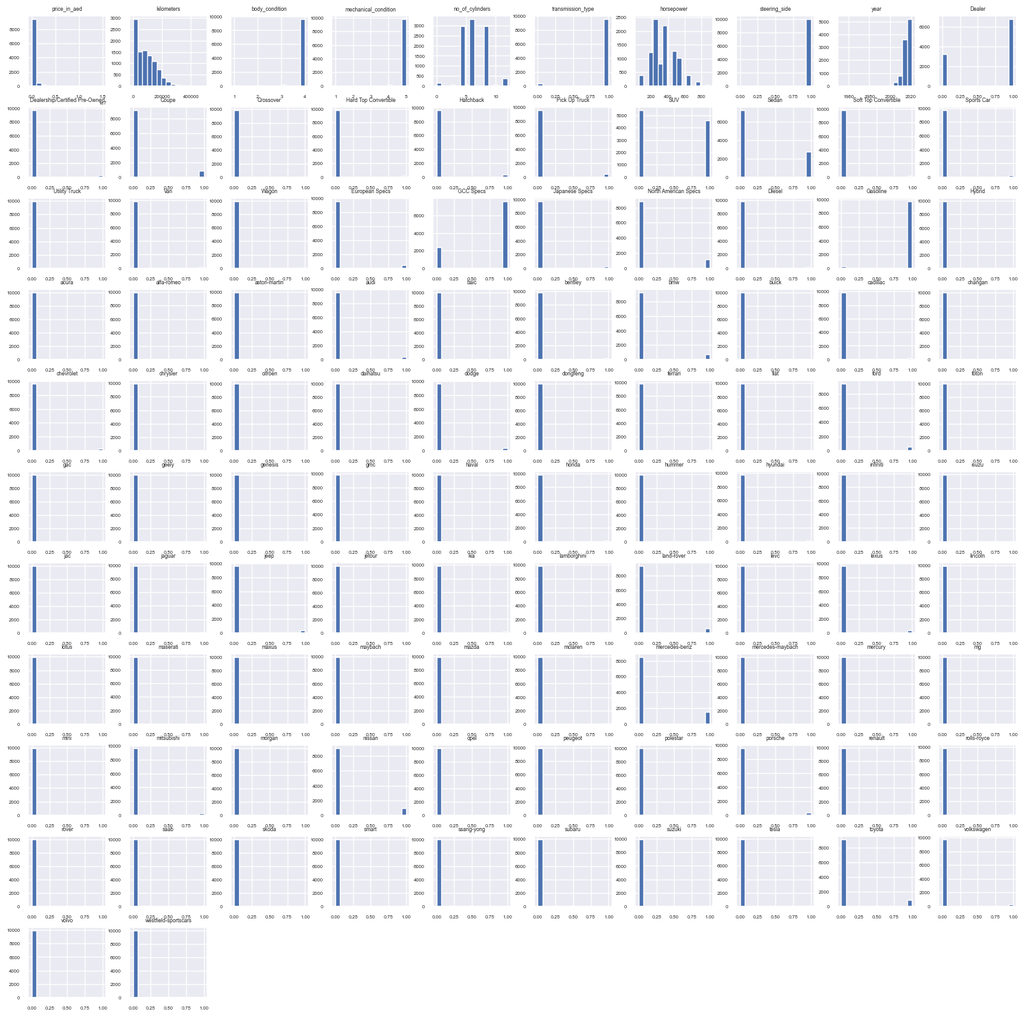

```python
predictor_names = df.columns

df.hist(predictor_names, bins = 15, figsize= (20,20))
plt.show()
```

We would like to observe maximum and minimum values and statistically describe our dataset.

```python
df.describe()
```

|  | price_in_aed | kilometers | body_condition | mechanical_condition | no_of_cylinders | transmission_type | horsepower | steering_side | year | Dealer | Dealership/Certified Pre-Owned | Coupe | Crossover | Hard Top Convertible | Hatchback | Pick Up Truck | SUV | Sedan | Soft Top Convertible | Sports Car | Utility Truck | Van | Wagon | European Specs | GCC Specs | Japanese Specs | North American Specs | Diesel | Gasoline | … |
| --- | --- | --- | --- | --- | --- | --- | --- | --- | --- | --- | --- | --- | --- | --- | --- | --- | --- | --- | --- | --- | --- | --- | --- | --- | --- | --- | --- | --- | --- | --- |
| count | 9.955000e+03 | 9955.000000 | 9955.000000 | 9955.000000 | 9955.000000 | 9955.000000 | 9955.000000 | 9955.000000 | 9955.000000 | 9955.000000 | 9955.000000 | 9955.000000 | 9955.000000 | 9955.000000 | 9955.000000 | 9955.000000 | 9955.000000 | 9955.000000 | 9955.000000 | 9955.000000 | 9955.000000 | 9955.000000 | 9955.000000 | 9955.000000 | 9955.000000 | 9955.000000 | 9955.000000 | 9955.000000 | 9955.000000 | … |
| mean | 2.483374e+05 | 85769.210648 | 3.946359 | 4.982722 | 6.135711 | 0.961326 | 343.705821 | 0.999498 | 2015.861175 | 0.678754 | 0.027122 | 0.085485 | 0.011351 | 0.016273 | 0.034555 | 0.042793 | 0.458162 | 0.275640 | 0.014264 | 0.026118 | 0.002511 | 0.016173 | 0.006529 | 0.042391 | 0.762130 | 0.025013 | 0.115218 | 0.016675 | 0.972476 | … |
| std | 4.539303e+05 | 72344.462938 | 0.304239 | 0.160065 | 2.084166 | 0.192827 | 150.105720 | 0.022407 | 4.535199 | 0.466978 | 0.162447 | 0.279616 | 0.105940 | 0.126531 | 0.182660 | 0.202399 | 0.498272 | 0.446859 | 0.118584 | 0.159493 | 0.050052 | 0.126146 | 0.080544 | 0.201489 | 0.425801 | 0.156171 | 0.319301 | 0.128057 | 0.163612 | … |
| min | 8.900000e+03 | 0.000000 | 1.000000 | 1.000000 | 0.000000 | 0.000000 | 50.000000 | 0.000000 | 1953.000000 | 0.000000 | 0.000000 | 0.000000 | 0.000000 | 0.000000 | 0.000000 | 0.000000 | 0.000000 | 0.000000 | 0.000000 | 0.000000 | 0.000000 | 0.000000 | 0.000000 | 0.000000 | 0.000000 | 0.000000 | 0.000000 | 0.000000 | 0.000000 | … |
| 25% | 5.100000e+04 | 23021.500000 | 4.000000 | 5.000000 | 4.000000 | 1.000000 | 250.000000 | 1.000000 | 2014.000000 | 0.000000 | 0.000000 | 0.000000 | 0.000000 | 0.000000 | 0.000000 | 0.000000 | 0.000000 | 0.000000 | 0.000000 | 0.000000 | 0.000000 | 0.000000 | 0.000000 | 0.000000 | 1.000000 | 0.000000 | 0.000000 | 0.000000 | 1.000000 | … |
| 50% | 1.049000e+05 | 75950.000000 | 4.000000 | 5.000000 | 6.000000 | 1.000000 | 350.000000 | 1.000000 | 2017.000000 | 1.000000 | 0.000000 | 0.000000 | 0.000000 | 0.000000 | 0.000000 | 0.000000 | 0.000000 | 0.000000 | 0.000000 | 0.000000 | 0.000000 | 0.000000 | 0.000000 | 0.000000 | 1.000000 | 0.000000 | 0.000000 | 0.000000 | 1.000000 | … |
| 75% | 2.350000e+05 | 133000.000000 | 4.000000 | 5.000000 | 8.000000 | 1.000000 | 450.000000 | 1.000000 | 2019.000000 | 1.000000 | 0.000000 | 0.000000 | 0.000000 | 0.000000 | 0.000000 | 0.000000 | 1.000000 | 1.000000 | 0.000000 | 0.000000 | 0.000000 | 0.000000 | 0.000000 | 0.000000 | 1.000000 | 0.000000 | 0.000000 | 0.000000 | 1.000000 | … |
| max | 1.499900e+07 | 488735.000000 | 4.000000 | 5.000000 | 12.000000 | 1.000000 | 900.000000 | 1.000000 | 2021.000000 | 1.000000 | 1.000000 | 1.000000 | 1.000000 | 1.000000 | 1.000000 | 1.000000 | 1.000000 | 1.000000 | 1.000000 | 1.000000 | 1.000000 | 1.000000 | 1.000000 | 1.000000 | 1.000000 | 1.000000 | 1.000000 | 1.000000 | 1.000000 | … |

And with this step, we'll standartize only non-binary predictors.

```python
df_not_binary = df[['mechanical_condition','body_condition','no_of_cylinders','horsepower','kilometers','price_in_aed', 'year']]

for col_name in df_not_binary:
    df[col_name] = df[col_name] + 0.00001
    df[col_name] = boxcox(df[col_name])[0]
    df[col_name] = scale(df[col_name])

df.head(5)
```

|  | price_in_aed | kilometers | body_condition | mechanical_condition | no_of_cylinders | transmission_type | horsepower | steering_side | year | Dealer | Dealership/Certified Pre-Owned | Coupe | Crossover | Hard Top Convertible | Hatchback | Pick Up Truck | SUV | Sedan | Soft Top Convertible | Sports Car | Utility Truck | Van | Wagon | European Specs | GCC Specs | Japanese Specs | North American Specs | Diesel | Gasoline | … |
| --- | --- | --- | --- | --- | --- | --- | --- | --- | --- | --- | --- | --- | --- | --- | --- | --- | --- | --- | --- | --- | --- | --- | --- | --- | --- | --- | --- | --- | --- | --- |
| 0 | -1.504237 | 0.905530 | 0.19258 | 0.122001 | -0.014853 | 1 | -0.084869 | 1 | -0.748533 | 1 | 0 | 0 | 0 | 0 | 0 | 0 | 1 | 0 | 0 | 0 | 0 | 0 | 0 | 0 | 1 | 0 | 0 | 0 | 1 | … |
| 1 | 0.051477 | -0.121575 | 0.19258 | 0.122001 | 0.886864 | 1 | 0.750140 | 1 | 0.497094 | 1 | 0 | 0 | 0 | 0 | 0 | 0 | 1 | 0 | 0 | 0 | 0 | 0 | 0 | 0 | 0 | 0 | 1 | 0 | 1 | … |
| 2 | -0.279158 | 1.060761 | 0.19258 | 0.122001 | -0.014853 | 1 | 0.750140 | 1 | -0.510615 | 1 | 0 | 0 | 0 | 0 | 0 | 0 | 0 | 1 | 0 | 0 | 0 | 0 | 0 | 0 | 1 | 0 | 0 | 0 | 1 | … |
| 3 | 1.640534 | -0.323448 | 0.19258 | 0.122001 | 0.886864 | 1 | 1.849362 | 1 | 0.497094 | 1 | 0 | 0 | 0 | 1 | 0 | 0 | 0 | 0 | 0 | 0 | 0 | 0 | 0 | 0 | 1 | 0 | 0 | 0 | 1 | … |
| 4 | -1.214754 | 0.233772 | 0.19258 | 0.122001 | -0.998228 | 0 | -2.468062 | 1 | 1.036367 | 0 | 0 | 0 | 0 | 0 | 0 | 0 | 0 | 0 | 0 | 0 | 0 | 0 | 1 | 0 | 1 | 0 | 0 | 0 | 1 | … |

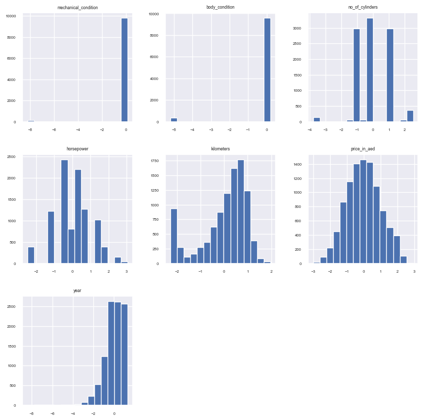

```python
predictor_names = df_not_binary.columns

df.hist(predictor_names, bins = 15, figsize= (10,10))
plt.show()

# First two graphs : 90% of the cars have perfect conditions in both mechanic_conditions and body_condition.
```

After all pre-processing, there is no missing value left in our dataset.

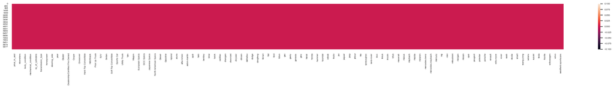

```python
fig, ax = plt.subplots(figsize=(30,2))
sns.heatmap(df.isnull(), ax=ax)
plt.show()
```

When we check the correlation matrix, we couldn't observe **high** correlated variables. So we didn't apply PCA. For example, there were slight correlation between:

- horsepower/cylinder number
- price/year

Since we are looking at automotive dataset, those are the slight correlations what we expected to see before we run our correlation matrix.

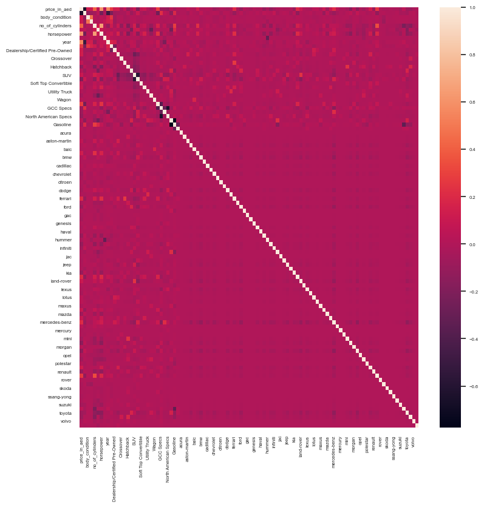

```python
corr_data=df.corr()
plt.figure(figsize=(9, 9))
sns.set(font_scale=0.5)
sns.heatmap(corr_data)
plt.show()
```

Before running regression models, we will split our data into test and train subsets.

```python
X = df.drop('price_in_aed', axis=1)
y = df['price_in_aed']
X_train, X_test, y_train, y_test = train_test_split(X, y, test_size=0.2, random_state=42)
```

**5 - MODELS**

Model 1 : Linear Regression

```python
model_linear_reg = LinearRegression()
model_linear_reg.fit(X_train,y_train)
predicted_y_linear = model_linear_reg.predict(X_test)

print(f'For this model: \n  R squared: {r2_score(y_test, predicted_y_linear)}\n  RMSE : {np.sqrt(mean_squared_error(y_test, predicted_y_linear))} \n  MSE : {mean_squared_error(y_test, predicted_y_linear)}')

linear_compare = pd.DataFrame({'Actual': y_test, 'Predicted': predicted_y_linear})
linear_compare.head(5)
```

```
For this model:
  R squared: 0.8409856873088777
  RMSE : 0.39938949957863246
  MSE : 0.15951197237367046
```

|  | Actual | Predicted |
| --- | --- | --- |
| 4094 | -1.412752 | -1.377467 |
| 3155 | 0.300987 | 0.092862 |
| 5500 | 0.433426 | 0.859483 |
| 1256 | -0.949344 | -0.909302 |
| 5577 | -1.412752 | -1.083563 |

Model 2 : Ridge Regression

```python
model_ridge = Ridge()
model_ridge.fit(X_train,y_train)
predicted_y_ridge = model_ridge.predict(X_test)

print(f'For this model: \n  R squared: {r2_score(y_test, predicted_y_ridge)}\n  RMSE : {np.sqrt(mean_squared_error(y_test, predicted_y_ridge))} \n  MSE : {mean_squared_error(y_test, predicted_y_ridge)}')

ridge_compare = pd.DataFrame({'Actual': y_test, 'Predicted': predicted_y_ridge})
ridge_compare.head(5)
```

```
For this model:
  R squared: 0.8400069373518648
  RMSE : 0.4006167563629895
  MSE : 0.16049378547880286
```

|  | Actual | Predicted |
| --- | --- | --- |
| 4094 | -1.412752 | -1.361508 |
| 3155 | 0.300987 | 0.089679 |
| 5500 | 0.433426 | 0.855359 |
| 1256 | -0.949344 | -0.907451 |
| 5577 | -1.412752 | -1.078817 |

Model 3 : Lasso Regression

```python
# For Lasso regression, we've tried different alpha values (such as 0.01, 10, 100, and 0.1) We got best result with 0.01
model_lasso = Lasso(alpha=0.01)
model_lasso.fit(X_train,y_train)
predicted_y_lasso = model_lasso.predict(X_test)

print(f'For this model: \n  R squared: {r2_score(y_test, predicted_y_lasso)}\n  RMSE : {np.sqrt(mean_squared_error(y_test, predicted_y_lasso))} \n  MSE : {mean_squared_error(y_test, predicted_y_lasso)}')
lasso_compare = pd.DataFrame({'Actual': y_test, 'Predicted': predicted_y_lasso})
lasso_compare.head(5)
```

```
For this model:
  R squared: 0.7792869321207023
  RMSE : 0.47053567694712833
  MSE : 0.2214038232800923
```

|  | Actual | Predicted |
| --- | --- | --- |
| 4094 | -1.412752 | -1.128204 |
| 3155 | 0.300987 | -0.055481 |
| 5500 | 0.433426 | 0.842640 |
| 1256 | -0.949344 | -0.636046 |
| 5577 | -1.412752 | -0.821127 |

Model 4: Elastic Net

```python
model_elasticnet = ElasticNet()
model_elasticnet.fit(X_train,y_train)
predicted_y_elastic= model_elasticnet.predict(X_test)

print(f'For this model: \n  R squared: {r2_score(y_test, predicted_y_elastic)}\n  RMSE : {np.sqrt(mean_squared_error(y_test, predicted_y_elastic))} \n  MSE : {mean_squared_error(y_test, predicted_y_elastic)}')

elasticnet_compare =  pd.DataFrame({'Actual': y_test, 'Predicted': predicted_y_elastic})
elasticnet_compare.head(5)
```

```
For this model:
  R squared: 0.160402920562839
  RMSE : 0.9177280246793558
  MSE : 0.8422247272818723
```

|  | Actual | Predicted |
| --- | --- | --- |
| 4094 | -1.412752 | -0.028091 |
| 3155 | 0.300987 | 0.002078 |
| 5500 | 0.433426 | 0.122064 |
| 1256 | -0.949344 | -0.078617 |
| 5577 | -1.412752 | -0.088466 |

**6 - MODEL EVALUATION**

```python
comparison = [
    ['Linear Regression',r2_score(y_test, predicted_y_linear), np.sqrt(mean_squared_error(y_test, predicted_y_linear)),mean_squared_error(y_test, predicted_y_linear),],
    ['Ridge', r2_score(y_test, predicted_y_ridge), np.sqrt(mean_squared_error(y_test, predicted_y_ridge)),mean_squared_error(y_test, predicted_y_ridge),],
    ['Lasso', r2_score(y_test, predicted_y_lasso), np.sqrt(mean_squared_error(y_test, predicted_y_lasso)),mean_squared_error(y_test, predicted_y_lasso),],
    ['ElasticNet', r2_score(y_test, predicted_y_elastic), np.sqrt(mean_squared_error(y_test, predicted_y_elastic)),mean_squared_error(y_test, predicted_y_elastic),]

]

titles = ['Model', 'R square', 'RMSE', 'MSE']

# display table
print(tabulate(comparison, headers=titles, tablefmt="grid"))
```

```
+-------------------+------------+----------+----------+
| Model             |   R square |     RMSE |      MSE |
+===================+============+==========+==========+
| Linear Regression |   0.840986 | 0.399389 | 0.159512 |
+-------------------+------------+----------+----------+
| Ridge             |   0.840007 | 0.400617 | 0.160494 |
+-------------------+------------+----------+----------+
| Lasso             |   0.779287 | 0.470536 | 0.221404 |
+-------------------+------------+----------+----------+
| ElasticNet        |   0.160403 | 0.917728 | 0.842225 |
+-------------------+------------+----------+----------+
```

**7 - CONCLUSION**

When we run multiple regression models on dataset, we expect to find best model which gives lowest RMSE score and highest R-square result. As we know:

- R-square shows us the percentage of variance in the outcome that is explained by the predictor variables. So, better R-square means better fit.
- RMSE measures the average difference between values predicted by a model and the actual values. It provides an estimation of how well the model is able to predict the target value (accuracy),where the closer the score is to 0 the better performing the model is. So the RMSE value should be as low as possible.

In our regression results, if we rank highest R-square value and lowest RMSE, we get :

1) **Linear** 2) **Ridge** 3) **Lasso**

- The evaluation values for Linear Regression show that it is a good fit for our dataset. But high R-square might show overfitting. To be sure, we also used Lasso and Ridge models.
- We had large number of predictors in our models in this project. To prevent overfitting and reduce the impact of outliers, we also wanted to use Lasso and Ridge, since those models are useful when we have large number of predictors. And penalty term we added could reduce the impact of noises in our dataset. The results for these models also show that they did good job to fit the data.
- However, We could not get good fit from ElasticNet model. The reason for this situation might be the ElasticNet models give better result when we have multicollinearity in dataset. But there was no multicollinearity among our predictors.